# Final Project

Data Mining - S21 A3

Group N: Chris Weddle (cweddle),Ravi Patel(rjpatel), Sanjana Parmar (sparmar2)

```r
library(ggplot2)
library(ggcorrplot)
library(GGally)
library(leaps)
library(splines)
library(plyr)
library(gam)
library(glmnet)
library(caret)
library(corrplot)
library(rpart)
library(randomForest)
library(pROC)
library(tidyverse)
library(dplyr)
library(knitr)
library(gridExtra)
library(class)
#library(cutpointr)


cbPalette <- c("#999999", "#E69F00", "#56B4E9", "#009E73", "#F0E442", "#0072B2", "#D55E00", "#CC79A7")

options(scipen = 4)
```

Problem Definition and Scope:

The network_traffic.csv file is a synopsis of logged network activity. It contains labeled examples of benign network sessions as well as examples of sessions involving intrusions. The bank observed while analyzing a year long record of logs, there were many instances of anomalous network activity that resulted in significant sums of money being siphoned from bank accounts. In this project we intend to analyze the data to address the following questions:

1. Is it possible to differentiate between the labeled intrusions and benign sessions?
2. Develop and implement a systematic approach to detect instances of intrusions in log files. Our system will be able to take a new network_traffic log file and determine the existence of known patterns of intrusions as well as anomalies which may be indicative of new and unknown intrusion patterns.
3. Evaluate detection power of our system.

```r
#Import the daa
traffic.full <- read.csv("network_traffic.csv")
set.seed(101)
summary(traffic.full)
```

```
##     duration       protocol_type        service              flag
##  Min.   :    0.0   Length:3000        Length:3000        Length:3000
##  1st Qu.:    0.0   Class :character   Class :character   Class :character
##  Median :    0.0   Mode  :character   Mode  :character   Mode  :character
##  Mean   :  118.1
##  3rd Qu.:    0.0
##  Max.   :24204.0
##    src_bytes          dst_bytes             land   wrong_fragment     urgent
##  Min.   :     0.0   Min.   :     0.0   Min.   :0   Min.   :0      Min.   :0
##  1st Qu.:   136.8   1st Qu.:   118.0   1st Qu.:0   1st Qu.:0      1st Qu.:0
##  Median :   228.0   Median :   388.5   Median :0   Median :0      Median :0
##  Mean   :  4567.8   Mean   :  2705.4   Mean   :0   Mean   :0      Mean   :0
##  3rd Qu.:   316.0   3rd Qu.:  1955.0   3rd Qu.:0   3rd Qu.:0      3rd Qu.:0
##  Max.   :283618.0   Max.   :273544.0   Max.   :0   Max.   :0      Max.   :0
##       hot         num_failed_logins   logged_in      num_compromised
##  Min.   : 0.000   Min.   :0         Min.   :0.0000   Min.   :  0.0000
##  1st Qu.: 0.000   1st Qu.:0         1st Qu.:0.0000   1st Qu.:  0.0000
##  Median : 0.000   Median :0         Median :1.0000   Median :  0.0000
##  Mean   : 0.066   Mean   :0         Mean   :0.7177   Mean   :  0.2967
##  3rd Qu.: 0.000   3rd Qu.:0         3rd Qu.:1.0000   3rd Qu.:  0.0000
##  Max.   :25.000   Max.   :0         Max.   :1.0000   Max.   :884.0000
##    root_shell     su_attempted          num_root        num_file_creations
##  Min.   :0.000   Min.   :0.0000000   Min.   :  0.0000   Min.   :0.000
##  1st Qu.:0.000   1st Qu.:0.0000000   1st Qu.:  0.0000   1st Qu.:0.000
##  Median :0.000   Median :0.0000000   Median :  0.0000   Median :0.000
##  Mean   :0.001   Mean   :0.0006667   Mean   :  0.3477   Mean   :0.001
##  3rd Qu.:0.000   3rd Qu.:0.0000000   3rd Qu.:  0.0000   3rd Qu.:0.000
##  Max.   :1.000   Max.   :2.0000000   Max.   :975.0000   Max.   :1.000
##    num_shells        num_access_files   num_outbound_cmds is_host_login
##  Min.   :0.0000000   Min.   :0.000000   Min.   :0         Min.   :0
##  1st Qu.:0.0000000   1st Qu.:0.000000   1st Qu.:0         1st Qu.:0
##  Median :0.0000000   Median :0.000000   Median :0         Median :0
##  Mean   :0.0003333   Mean   :0.004667   Mean   :0         Mean   :0
##  3rd Qu.:0.0000000   3rd Qu.:0.000000   3rd Qu.:0         3rd Qu.:0
##  Max.   :1.0000000   Max.   :5.000000   Max.   :0         Max.   :0
##  is_guest_login  is_intrusion
##  Min.   :0.000   Length:3000
##  1st Qu.:0.000   Class :character
##  Median :0.000   Mode  :character
##  Mean   :0.015
##  3rd Qu.:0.000
##  Max.   :1.000
```

Data Cleaning:

We started the data cleaning with analysing the range of values in each variable, using the summary function. There were a number of variables that had very few non zero values and for that reason we decided to drop those columns.

```r
traffic <-subset(traffic.full, select = -c(land, wrong_fragment, urgent, num_failed_logins, num_outbound_cmds,is_host_login))
#Look for na values
sum(is.na(traffic))
```

```
## [1] 0
```

We went on to check for NA values in the remaining variables so that it doesnt cause a problem during the analysis.

we changed the character variables into factors to enable their usage in the following methods of analysis.

```r
discrete <- c("protocol_type", "service", "flag", "su_attempted", "root_shell", "is_guest_login", "is_intrusion", "logged_in")
traffic[,discrete] <- lapply(traffic[,discrete], factor)
summary(traffic)
```

```
##     duration       protocol_type     service       flag        src_bytes
##  Min.   :    0.0   icmp:  40     http    :1912   REJ : 154   Min.   :     0.0
##  1st Qu.:    0.0   tcp :2450     smtp    : 290   RSTO:   1   1st Qu.:   136.8
##  Median :    0.0   udp : 510     private : 247   RSTR:  65   Median :   228.0
##  Mean   :  118.1                 domain_u: 185   S0  :  33   Mean   :  4567.8
##  3rd Qu.:    0.0                 ftp_data: 169   S3  :   2   3rd Qu.:   316.0
##  Max.   :24204.0                 other   :  58   SF  :2745   Max.   :283618.0
##                                  (Other) : 139
##    dst_bytes             hot         logged_in num_compromised    root_shell
##  Min.   :     0.0   Min.   : 0.000   0: 847    Min.   :  0.0000   0:2997
##  1st Qu.:   118.0   1st Qu.: 0.000   1:2153    1st Qu.:  0.0000   1:   3
##  Median :   388.5   Median : 0.000             Median :  0.0000
##  Mean   :  2705.4   Mean   : 0.066             Mean   :  0.2967
##  3rd Qu.:  1955.0   3rd Qu.: 0.000             3rd Qu.:  0.0000
##  Max.   :273544.0   Max.   :25.000             Max.   :884.0000
##
##  su_attempted    num_root        num_file_creations   num_shells
##  0:2999       Min.   :  0.0000   Min.   :0.000      Min.   :0.0000000
##  2:   1       1st Qu.:  0.0000   1st Qu.:0.000      1st Qu.:0.0000000
##               Median :  0.0000   Median :0.000      Median :0.0000000
##               Mean   :  0.3477   Mean   :0.001      Mean   :0.0003333
##               3rd Qu.:  0.0000   3rd Qu.:0.000      3rd Qu.:0.0000000
##               Max.   :975.0000   Max.   :1.000      Max.   :1.0000000
##
##  num_access_files   is_guest_login is_intrusion
##  Min.   :0.000000   0:2955         0 :2699
##  1st Qu.:0.000000   1:  45         0=:   1
##  Median :0.000000                  1 : 300
##  Mean   :0.004667
##  3rd Qu.:0.000000
##  Max.   :5.000000
##
```

To get an idea of the distribution of values in different variables we plot them and check for number of non zero values.

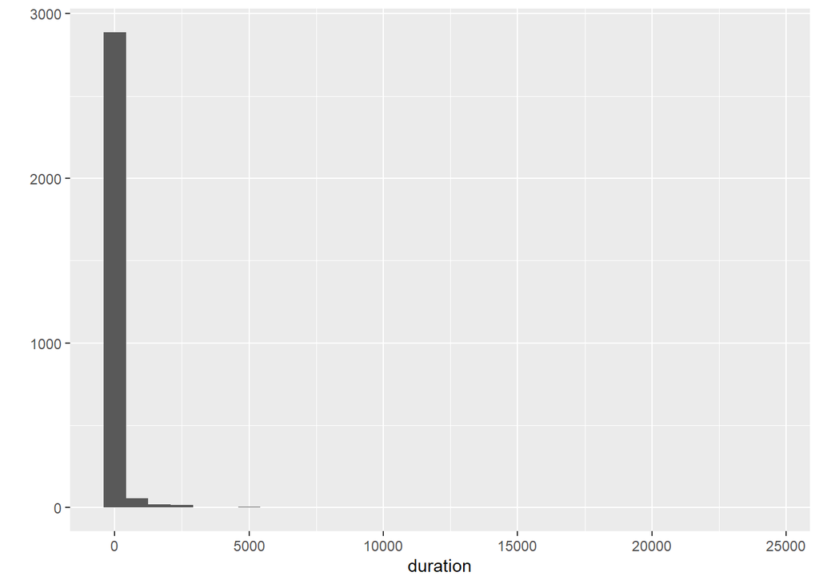

```r
qplot(duration, data = traffic)
```

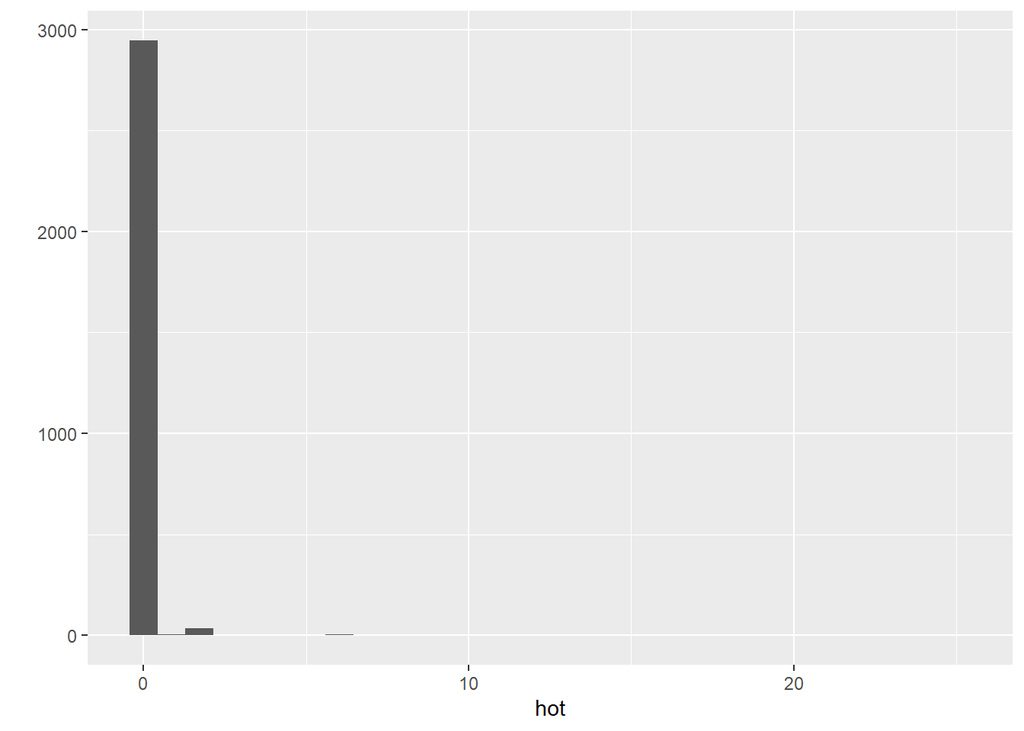

```r
qplot(hot, data=traffic)
```

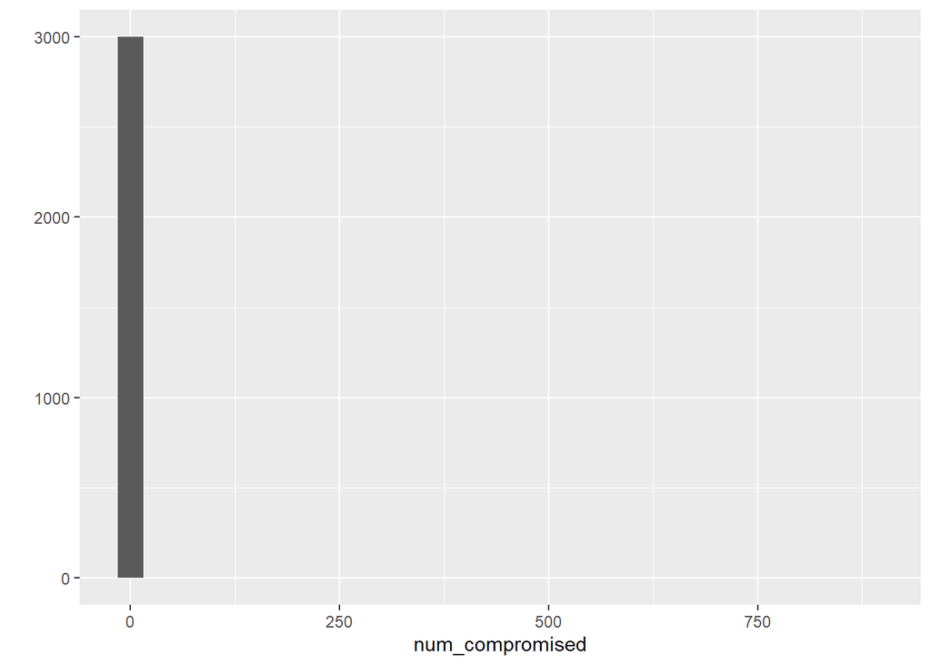

```r
qplot(num_compromised, data=traffic)
```

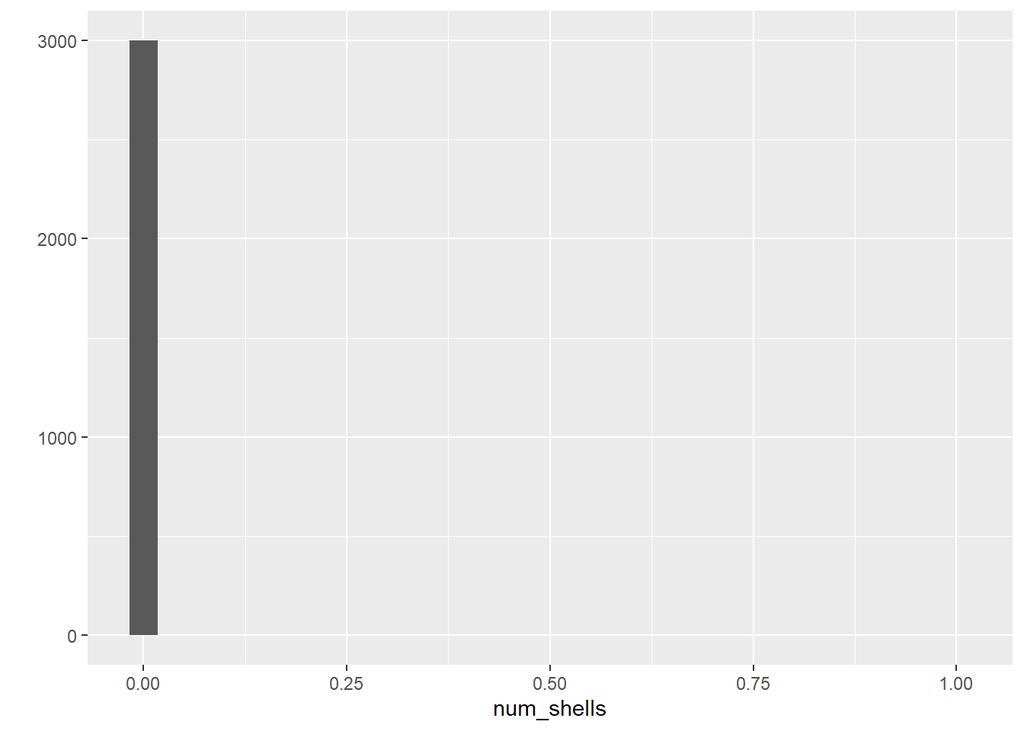

```r
qplot(num_shells, data=traffic)
```

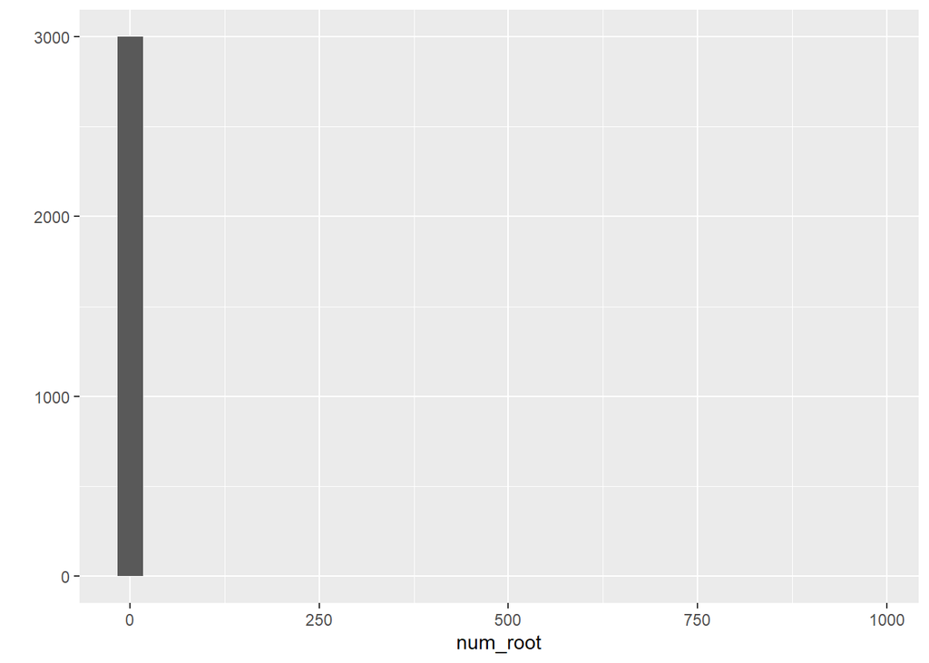

```r
qplot(num_root, data=traffic)
```

```r
length(traffic$num_compromised[traffic$num_compromised > 0])
```

```
## [1] 4
```

```r
length(traffic$num_root[traffic$num_root > 0])
```

```
## [1] 20
```

```r
length(traffic$num_root[traffic$num_root > 1])
```

```
## [1] 9
```

```r
length(traffic$num_file_creations[traffic$num_file_creations > 0])
```

```
## [1] 3
```

```r
length(traffic$num_access_files[traffic$num_access_files > 0])
```

```
## [1] 9
```

```r
length(traffic$num_access_files[traffic$num_access_files > 1])
```

```
## [1] 2
```

```r
length(traffic$num_shells[traffic$num_shells > 0])
```

```
## [1] 1
```

```r
length(traffic$hot[traffic$hot > 0])
```

```
## [1] 55
```

We observed that, num_compromised: 4 points > 0 num_root: 20 points > 0 num_root: 9 points > 1 num_file_creations: 3 points > 0 num_access_files: 9 points > 0 num_access_files: 2 points > 1 hot: 55 points > 0

Get rid of num_compromised and num_file_creations

num_root has 20 points > 0, and 9 points > 1. It has one very high value, 975. Change this into a factor of Zero and Non-Zero.

num_access_files has 9 points > 0. This will be left as it is for now.

num_shells only have 1 value > 0. Drop this column.

Hot has enough points > 0 to be left as it is.

su_attempted a single 2, and this is not valid. Drop the column. root_shell only has 3 points with 1. Drop the column.

Dropping a few additonal columns

```r
traffic <- subset(traffic, select = -c(num_compromised, num_file_creations, su_attempted, root_shell, num_shells))
fact.list <- c("num_root")
traffic$num_root <- ifelse(traffic$num_root==0, "Zero", "Non-Zero")
traffic$num_root <-factor(traffic$num_root)
summary(traffic)
```

```
##     duration       protocol_type     service       flag        src_bytes
##  Min.   :    0.0   icmp:  40     http    :1912   REJ : 154   Min.   :     0.0
##  1st Qu.:    0.0   tcp :2450     smtp    : 290   RSTO:   1   1st Qu.:   136.8
##  Median :    0.0   udp : 510     private : 247   RSTR:  65   Median :   228.0
##  Mean   :  118.1                 domain_u: 185   S0  :  33   Mean   :  4567.8
##  3rd Qu.:    0.0                 ftp_data: 169   S3  :   2   3rd Qu.:   316.0
##  Max.   :24204.0                 other   :  58   SF  :2745   Max.   :283618.0
##                                  (Other) : 139
##    dst_bytes             hot         logged_in     num_root
##  Min.   :     0.0   Min.   : 0.000   0: 847    Non-Zero:  20
##  1st Qu.:   118.0   1st Qu.: 0.000   1:2153    Zero    :2980
##  Median :   388.5   Median : 0.000
##  Mean   :  2705.4   Mean   : 0.066
##  3rd Qu.:  1955.0   3rd Qu.: 0.000
##  Max.   :273544.0   Max.   :25.000
##
##  num_access_files   is_guest_login is_intrusion
##  Min.   :0.000000   0:2955         0 :2699
##  1st Qu.:0.000000   1:  45         0=:   1
##  Median :0.000000                  1 : 300
##  Mean   :0.004667
##  3rd Qu.:0.000000
##  Max.   :5.000000
##
```

Recoding variable values:

flag: combine into “normal” or “error”

```r
traffic <- mutate(traffic,
                  is_intrusion = recode_factor(is_intrusion,
                                               "0" = "0",
                                               "0=" = "0",
                                               "1" = "1"))
traffic <- mutate(traffic,
                  flag = recode_factor(flag,
                                        "SF"= "SF",
                                       .default = "Error"))


summary(traffic)
```

```
##     duration       protocol_type     service        flag
##  Min.   :    0.0   icmp:  40     http    :1912   SF   :2745
##  1st Qu.:    0.0   tcp :2450     smtp    : 290   Error: 255
##  Median :    0.0   udp : 510     private : 247
##  Mean   :  118.1                 domain_u: 185
##  3rd Qu.:    0.0                 ftp_data: 169
##  Max.   :24204.0                 other   :  58
##                                  (Other) : 139
##    src_bytes          dst_bytes             hot         logged_in
##  Min.   :     0.0   Min.   :     0.0   Min.   : 0.000   0: 847
##  1st Qu.:   136.8   1st Qu.:   118.0   1st Qu.: 0.000   1:2153
##  Median :   228.0   Median :   388.5   Median : 0.000
##  Mean   :  4567.8   Mean   :  2705.4   Mean   : 0.066
##  3rd Qu.:   316.0   3rd Qu.:  1955.0   3rd Qu.: 0.000
##  Max.   :283618.0   Max.   :273544.0   Max.   :25.000
##
##      num_root    num_access_files   is_guest_login is_intrusion
##  Non-Zero:  20   Min.   :0.000000   0:2955         0:2700
##  Zero    :2980   1st Qu.:0.000000   1:  45         1: 300
##                  Median :0.000000
##                  Mean   :0.004667
##                  3rd Qu.:0.000000
##                  Max.   :5.000000
##
```

```r
levels(traffic$service)
```

```
##  [1] "auth"     "domain_u" "eco_i"    "ecr_i"    "finger"   "ftp"
##  [7] "ftp_data" "http"     "ntp_u"    "other"    "pop_3"    "private"
## [13] "smtp"     "telnet"   "time"     "urp_i"
```

Keep only “http”, “smtp”, “private”, “domain_u”, and “ftp_data” from “service”. Make everything else “other”.

```r
traffic <- mutate(traffic,
                  service = recode_factor(service,
                                        "http"= "http",
                                        "smtp" = "smtp",
                                        "private" = "private",
                                        "domain_u" = "domain_u",
                                        "ftp_data" = "ftp_data",
                                       .default = "other"))
summary(traffic)
```

```
##     duration       protocol_type     service        flag
##  Min.   :    0.0   icmp:  40     http    :1912   SF   :2745
##  1st Qu.:    0.0   tcp :2450     smtp    : 290   Error: 255
##  Median :    0.0   udp : 510     private : 247
##  Mean   :  118.1                 domain_u: 185
##  3rd Qu.:    0.0                 ftp_data: 169
##  Max.   :24204.0                 other   : 197
##    src_bytes          dst_bytes             hot         logged_in
##  Min.   :     0.0   Min.   :     0.0   Min.   : 0.000   0: 847
##  1st Qu.:   136.8   1st Qu.:   118.0   1st Qu.: 0.000   1:2153
##  Median :   228.0   Median :   388.5   Median : 0.000
##  Mean   :  4567.8   Mean   :  2705.4   Mean   : 0.066
##  3rd Qu.:   316.0   3rd Qu.:  1955.0   3rd Qu.: 0.000
##  Max.   :283618.0   Max.   :273544.0   Max.   :25.000
##      num_root    num_access_files   is_guest_login is_intrusion
##  Non-Zero:  20   Min.   :0.000000   0:2955         0:2700
##  Zero    :2980   1st Qu.:0.000000   1:  45         1: 300
##                  Median :0.000000
##                  Mean   :0.004667
##                  3rd Qu.:0.000000
##                  Max.   :5.000000
```

```r
colnames(traffic)
```

```
##  [1] "duration"         "protocol_type"    "service"          "flag"
##  [5] "src_bytes"        "dst_bytes"        "hot"              "logged_in"
##  [9] "num_root"         "num_access_files" "is_guest_login"   "is_intrusion"
```

Data Analysis

Let us start with analysing how some of the variables are distributed in the dataset by plotting histograms.

Histogram for the variables duration, hot and dst_bytes:

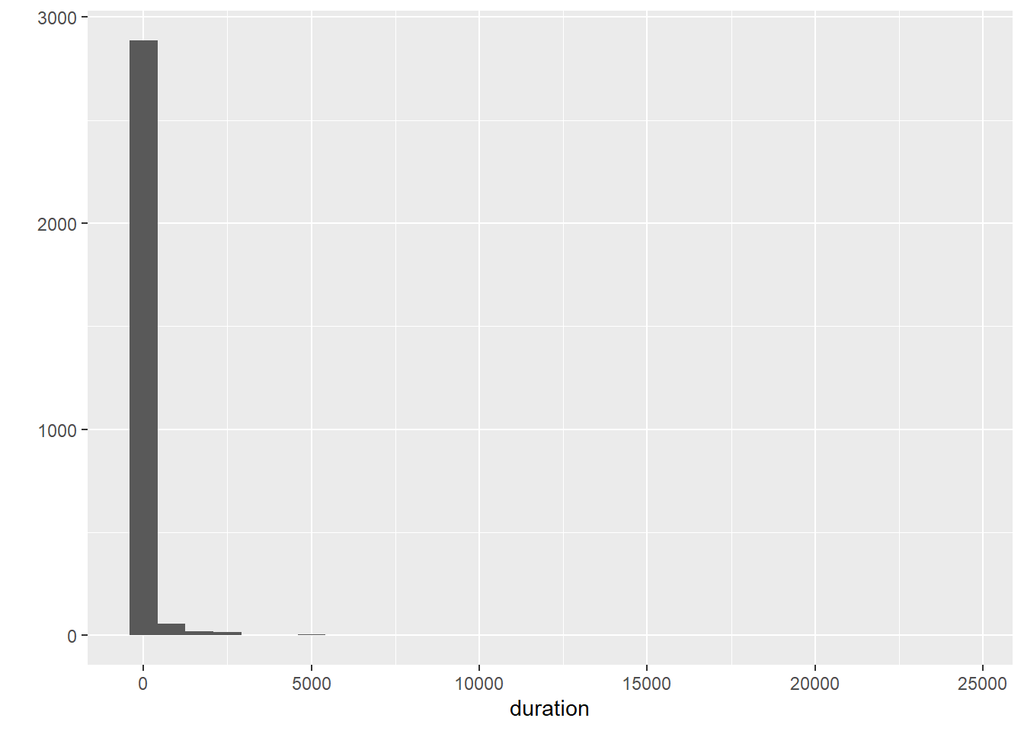

```r
qplot(duration, data = traffic)
```

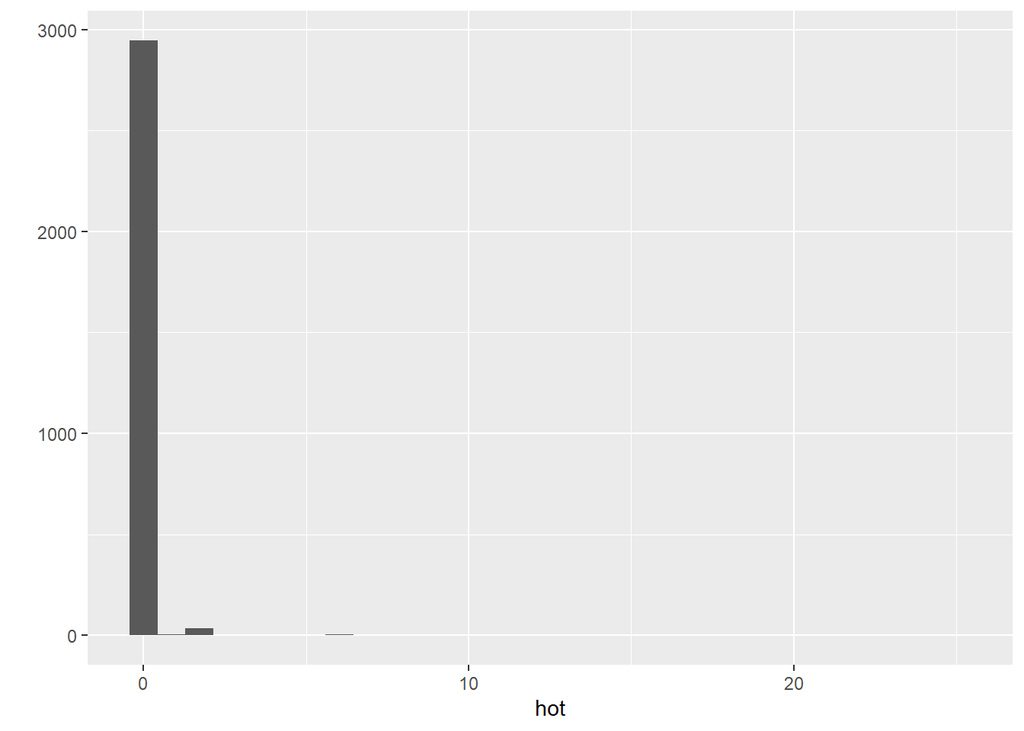

```r
qplot(hot, data=traffic)
```

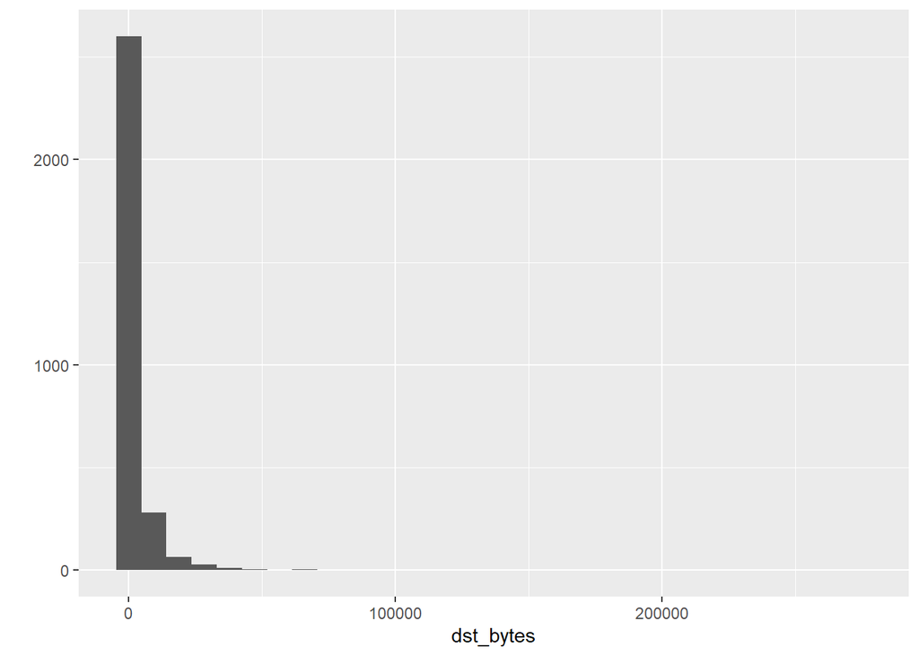

```r
qplot(dst_bytes, data=traffic)
```

The duration of the connection is very skewed to the right, but these high values might be important.

The number of hot connections is similarly skewed, as is dst_bytes.Most of this data is very close to 0.

Next, lets plot a correlation matrix of the numerical variables in the dataset:

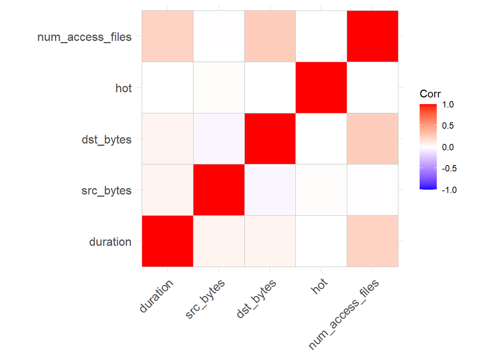

```r
cor.mat <- cor(traffic[sapply(traffic, is.numeric)])

ggcorrplot(cor.mat)
```

```r
correlations <- c()
for(i in 1:nrow(cor.mat)) {
  correlations <- append(correlations, which((cor.mat[i,] != 1 & (cor.mat[i,] >= .8 | cor.mat[i,] <=-.8))))
}

for(i in 1:nrow(cor.mat)) {
  for(j in 1:ceiling(ncol(cor.mat)/2)) {
    if((cor.mat[i,j] >= .8 | cor.mat[i,j] <= -.8) & cor.mat[i,j] < 1) {
      print(c(rownames(cor.mat)[i], colnames(cor.mat)[j], cor.mat[i,j]))
    }
  }
}
```

None of our numerical data is very strongly correlated. We don’t have to worry about correlations between these variables.

Pairs plot for selected predictor variables, including some binary variables to check if there are any strong correlations among the predictor variables.

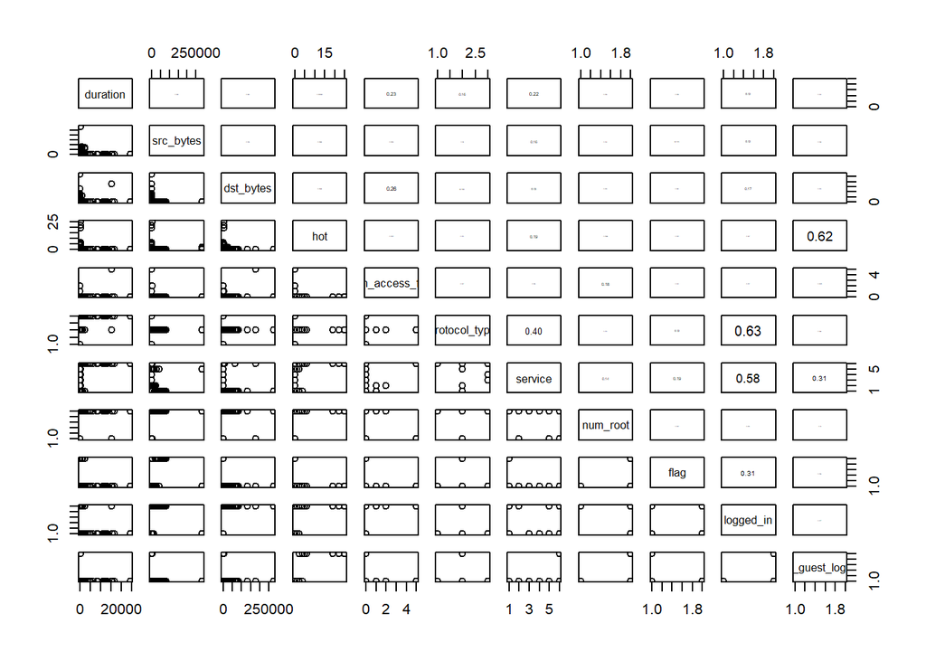

```r
#Function take from ?pairs library on R
panel.cor <- function(x, y, digits = 2, prefix = "", cex.cor, ...) {
    usr <- par("usr"); on.exit(par(usr))
    par(usr = c(0, 1, 0, 1))
    r <- abs(cor(x, y))
    txt <- format(c(r, 0.123456789), digits = digits)[1]
    txt <- paste0(prefix, txt)
    if(missing(cex.cor)) cex.cor <- 0.8/strwidth(txt)
    text(0.5, 0.5, txt, cex = cex.cor * r)
}




vars_2r <- c("duration", "src_bytes", "dst_bytes", "hot", "num_access_files", "protocol_type",
          "service", "num_root", "flag", "logged_in", "is_guest_login")
pairs_traffic <- traffic[vars_2r]

pairs(pairs_traffic, upper.panel = panel.cor)
```

Potential correlations: There may be important correlations between: protocol_type & logged_in service & logged_in hot & is_guest_login

However, none of these correlations is high enough to remove one of these columns from the data.

Now checking for correlations with the response variable is_intrusion:

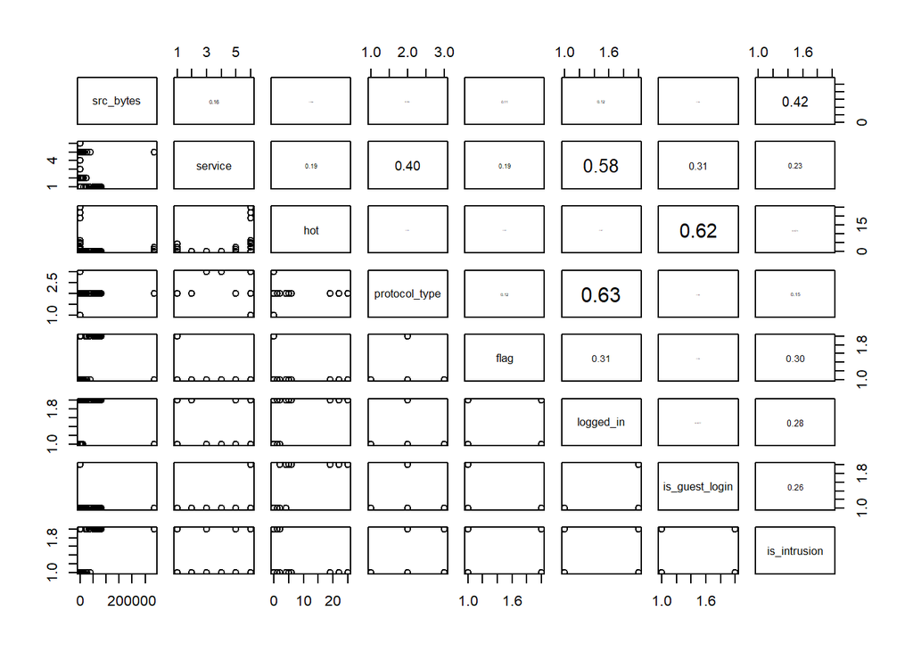

```r
vars.2 <- c("src_bytes", "service", "hot", "protocol_type", "flag", "logged_in", "is_guest_login", "is_intrusion")
pairs_traffic <- traffic[vars.2]

pairs(pairs_traffic, upper.panel = panel.cor)
```

Src_bytes has a correlation of 0.42 with is_intrusion. This may be an important variable to consider when detecting intrusions. For further analysis of the association between these two variables, let us create side-by-side boxplots to explore the association between the two variables src_bytes and is_intrusion:

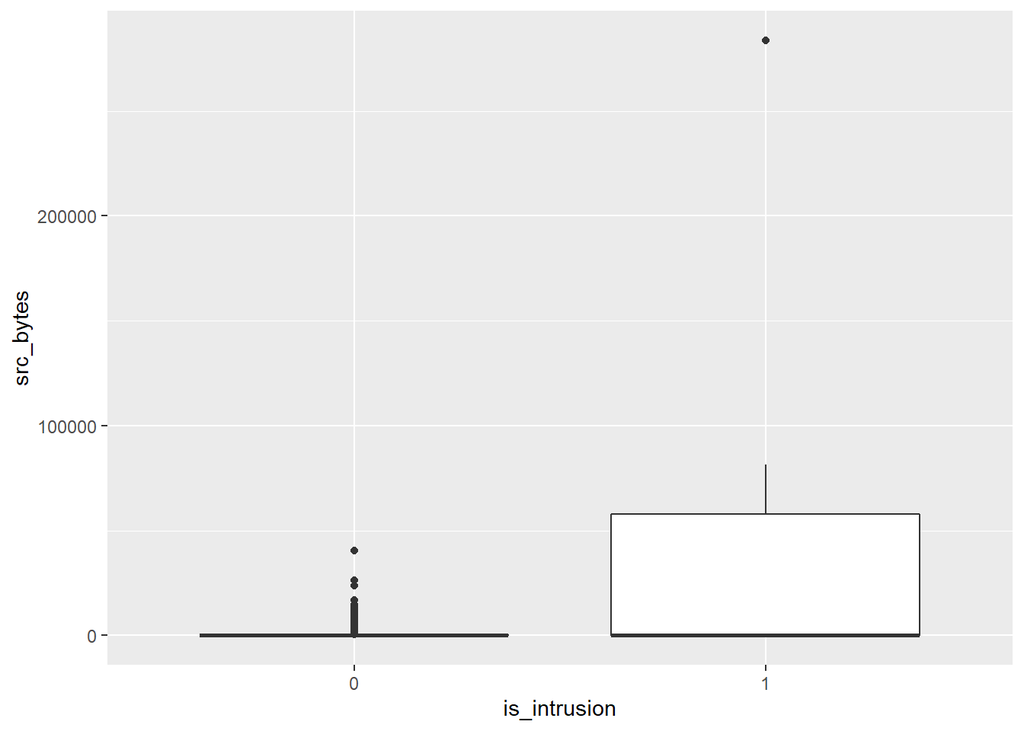

```r
ggplot(traffic, aes(x=is_intrusion, y= src_bytes))+
  geom_boxplot()
```

This boxplot indicates that high numbers of src_bytes is a good indication of an intrusion.

Split src_bytes into bins, see how the bytes are associated with is_intrusion.

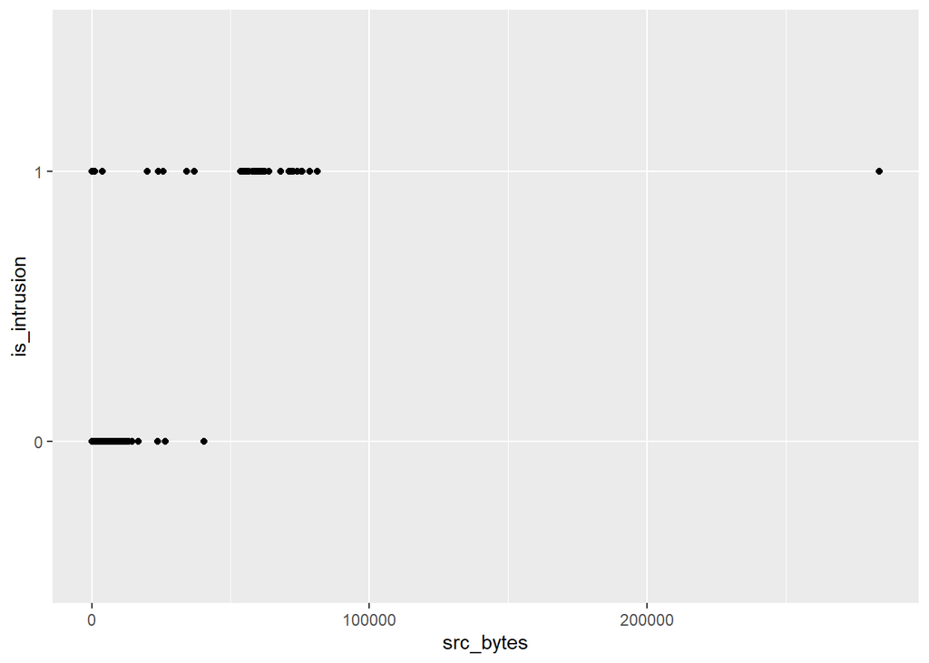

```r
ggplot(traffic, aes(x = src_bytes, y = is_intrusion)) +
  geom_point()
```

Very high number of intrusions are associated with the src_bytes value range from 50,000 to 80,000.

Exploring association between dst_bytes and is_intrusion with side-by-side boxplot:

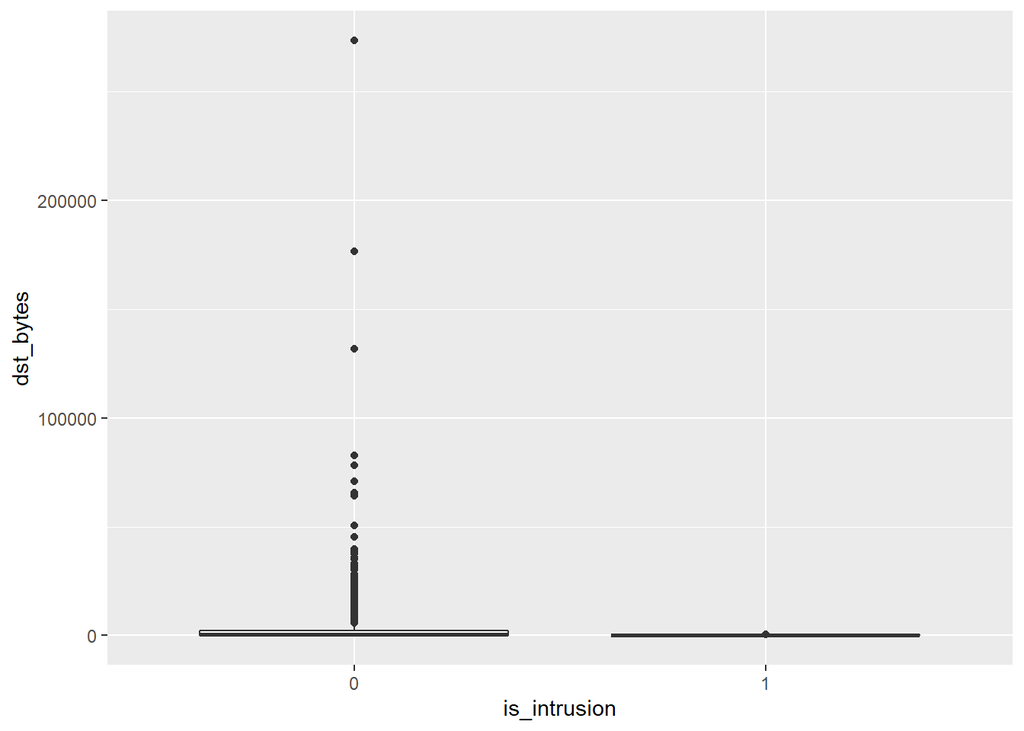

```r
ggplot(traffic, aes(x=is_intrusion, y= dst_bytes))+
  geom_boxplot()
```

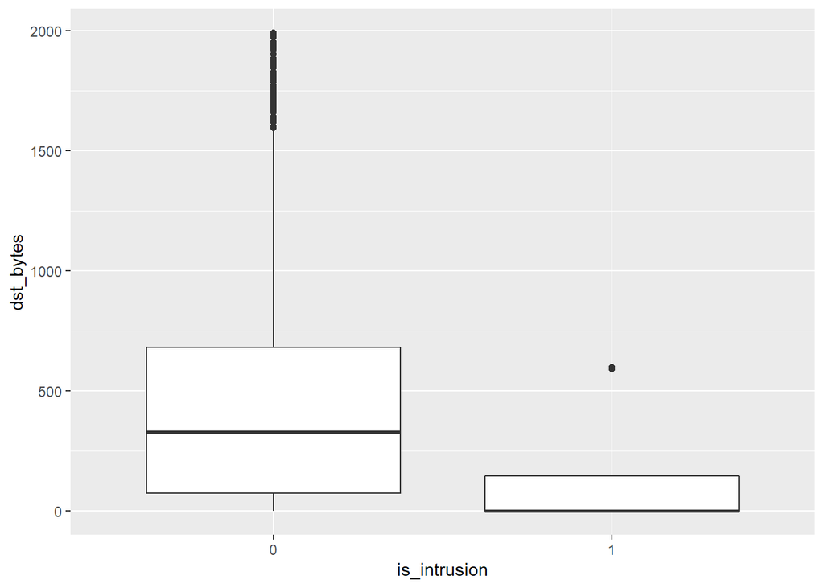

```r
traffic_plot_r = traffic

traffic_plot_r <- traffic_plot_r %>% filter(dst_bytes < 2000)

ggplot(traffic_plot_r, aes(x=is_intrusion, y= dst_bytes))+
  geom_boxplot()
```

Although the two boxplots overlap, the occurrence of intrusion is associated with relatively lower values of dst_bytes.

Next, plotting a bar graph to explore association between the variables logged_in and is_intrusion.

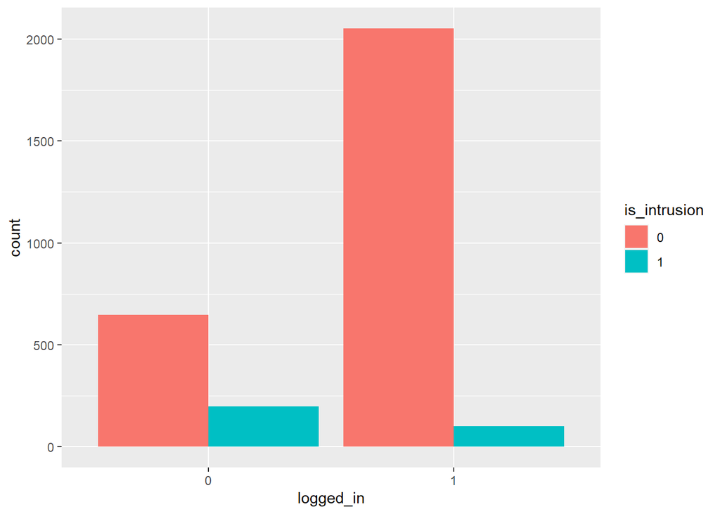

```r
ggplot(data=traffic, aes(x=logged_in,fill=is_intrusion)) +
  geom_bar(position="dodge")
```

When a case is not logged in, the chances of it being an intrusion are much higher than if someone is logged in.

Similarly, plotting a bar graph to explore association between the variables flag and is_intrusion.

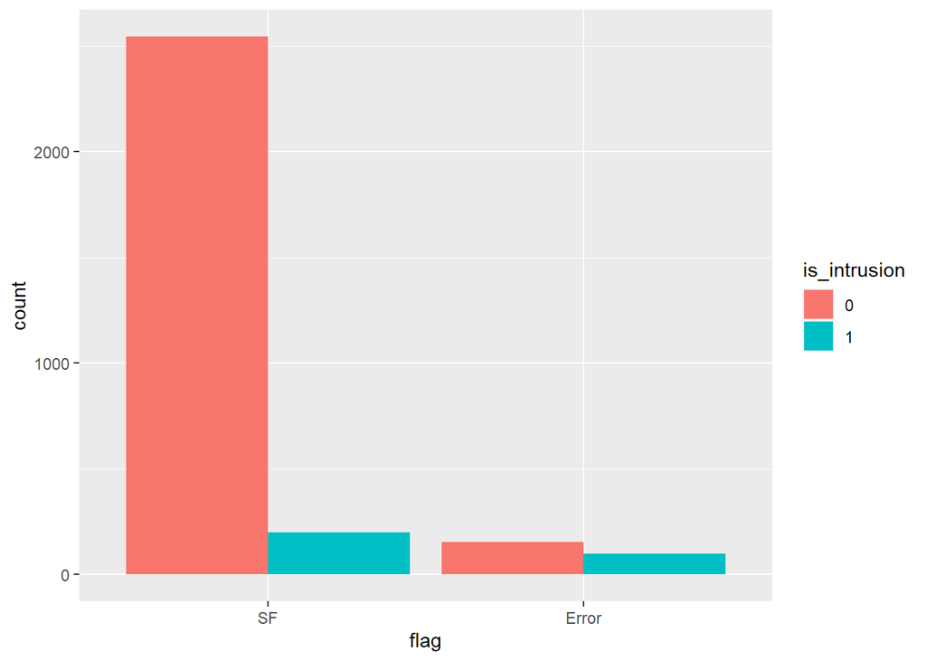

```r
ggplot(data=traffic, aes(x=flag,fill=is_intrusion)) +
  geom_bar(position="dodge")
```

There were many types of flags in the data, but having any kind of flag associated with the connection makes the chances of the connection being an intrusion much higher.

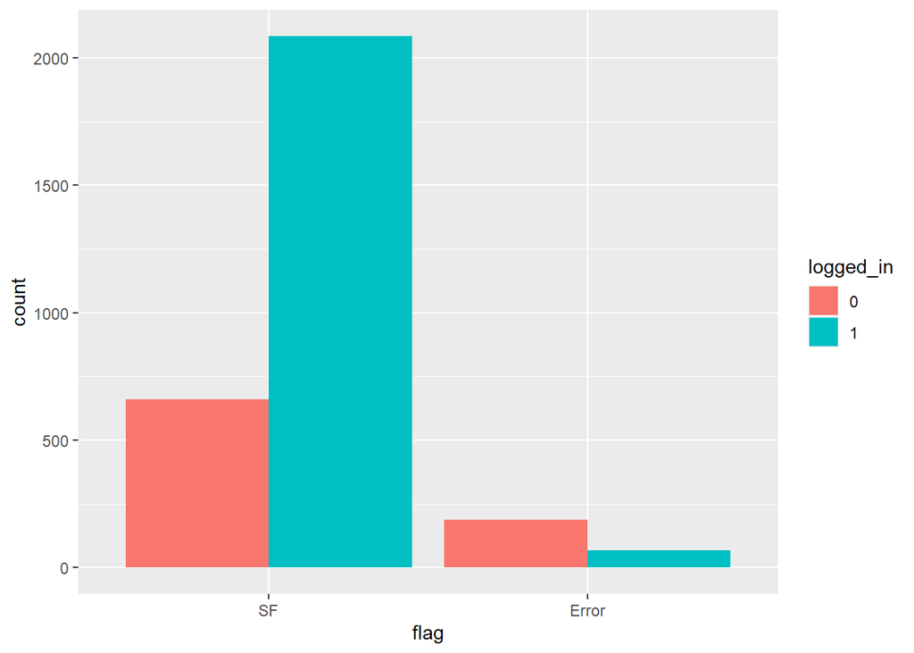

```r
ggplot(data=traffic, aes(x=flag,fill=logged_in)) +
  geom_bar(position="dodge")
```

Although flag and logged_in do not have very high correlation value, proportion of instances with logged_in as 1 have high association with flag being marked as SF.

Now, checking how different values of the categorical variable service are associated with is_intrusion.

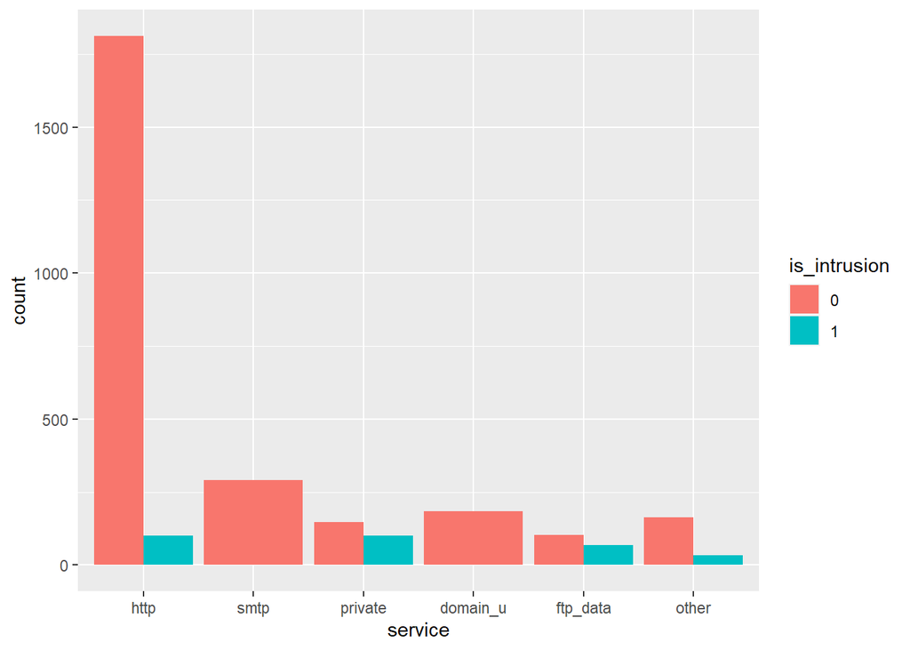

```r
ggplot(data=traffic, aes(x=service,fill=is_intrusion)) +
  geom_bar(position="dodge")
```

From the above plot, we can observe that the values private and ftp_data of the variable service have high association with event of intrusion.

Now, checking for the number of positive values for the variables num_access_files and hot.

```r
length(traffic$num_access_files[traffic$num_access_files > 0])
```

```
## [1] 9
```

```r
length(traffic$hot[traffic$hot > 0])
```

```
## [1] 55
```

```r
length(traffic$num_root[traffic$num_root == "Non-Zero"])
```

```
## [1] 20
```

```r
# colnames(traffic)
```

num_access_files has 9 values greater than 0. num_root has 20 non-zero values. Consider removing num_access_files and num_root later for better model performance.

The variable hot has 55 positive values which is not as low as num_access_files and num_root.

Split the data into 20% testing and 80% training data

```r
test.indexes <- sample(1:nrow(traffic), round(0.2*nrow(traffic)))
traffic.test <- traffic[test.indexes,]
traffic.train <- traffic[-test.indexes,]
```

Do all of the model training on traffic.train

Logistic regression, try different cutoffs It is more important to correctly identify intrusions than correctly identify not-intrusions (TPP more important than True Negative) Change this by altering the cutoff for logistic regression

There is a problem with logistic regression instibility if you include any of these variables in the fit

```r
glm.allfit <- glm(is_intrusion~ ., family = binomial, data = traffic.train)
kable(coef(summary(glm.allfit)))
```

|  | Estimate | Std. Error | z value | Pr(>\|z\|) |
| --- | --- | --- | --- | --- |
| (Intercept) | -3241.2722474 | 14811.7253136 | -0.2188315 | 0.8267813 |
| duration | 0.0355280 | 0.0300576 | 1.1819988 | 0.2372062 |
| protocol_typetcp | -1010.3650749 | 14741.4076118 | -0.0685393 | 0.9453564 |
| protocol_typeudp | -855.2309785 | 14055.2606521 | -0.0608477 | 0.9514805 |
| servicesmtp | 4237.8359860 | 2481.1990399 | 1.7079791 | 0.0876402 |
| serviceprivate | 4105.1304817 | 6731.2425470 | 0.6098622 | 0.5419531 |
| servicedomain_u | 4082.0626907 | 7993.7685874 | 0.5106556 | 0.6095922 |
| serviceftp_data | 4263.1379906 | 1789.4586268 | 2.3823619 | 0.0172020 |
| serviceother | 3228.7993939 | 5802.3465886 | 0.5564644 | 0.5778934 |
| flagError | 4261.1676949 | 1789.4667347 | 2.3812500 | 0.0172540 |
| src_bytes | -0.0000084 | 0.0000347 | -0.2433788 | 0.8077120 |
| dst_bytes | 0.0155782 | 0.0056603 | 2.7521591 | 0.0059204 |
| hot | -2.5385571 | 1.1560959 | -2.1958016 | 0.0281061 |
| logged_in1 | -13.8951215 | 94.6118700 | -0.1468645 | 0.8832390 |
| num_rootZero | -11.0925551 | 94.6152475 | -0.1172386 | 0.9066710 |
| num_access_files | -455.0656789 | 8557.2126255 | -0.0531792 | 0.9575891 |
| is_guest_login1 | 1040.2136183 | 5620.5732794 | 0.1850725 | 0.8531722 |

```r
glm.allprob <- predict(glm.allfit, traffic.train, type="response")
glm.allpred <- rep(0, nrow(traffic.train))
glm.allpred[glm.allprob>.3] = 1
table(glm.allpred, traffic.train$is_intrusion)
```

```
##
## glm.allpred    0    1
##           0 2042   27
##           1  115  216
```

Logistic Regression with Best Subset Selection

```r
glm.subset <- regsubsets(is_intrusion~.,
                         data = traffic.train,
                         nbest = 1,
                         nvmax = 29,
                         method="exhaustive")
summary(glm.subset)
```

```
## Subset selection object
## Call: regsubsets.formula(is_intrusion ~ ., data = traffic.train, nbest = 1,
##     nvmax = 29, method = "exhaustive")
## 16 Variables  (and intercept)
##                  Forced in Forced out
## duration             FALSE      FALSE
## protocol_typetcp     FALSE      FALSE
## protocol_typeudp     FALSE      FALSE
## servicesmtp          FALSE      FALSE
## serviceprivate       FALSE      FALSE
## servicedomain_u      FALSE      FALSE
## serviceftp_data      FALSE      FALSE
## serviceother         FALSE      FALSE
## flagError            FALSE      FALSE
## src_bytes            FALSE      FALSE
```

[output cut: 76 more lines]

When only one variable is used to predict intrusions, src_bytes is used. The second variable added to the regression is service: private. The third is is_guest_login = 1. The fourth is flag: Error.

```r
glm.summary <- summary(glm.subset)
glm.summary$rsq
```

```
##  [1] 0.1717984 0.2780138 0.3593750 0.4424030 0.4718483 0.4871336 0.4890779
##  [8] 0.4942355 0.4973018 0.4983832 0.4991966 0.4994531 0.4996078 0.4996133
## [15] 0.4996147 0.4996150
```

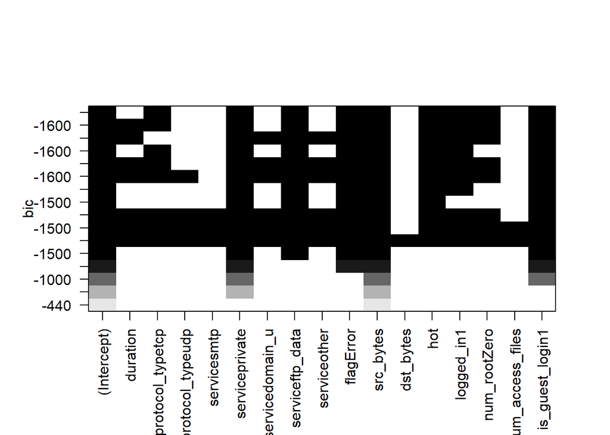

```r
plot(glm.subset)
```

dst_bytes only appears in one model, even though it seemed important in the full regression model. It might not be as important as it first seemed.

Graphing code taken from the homework

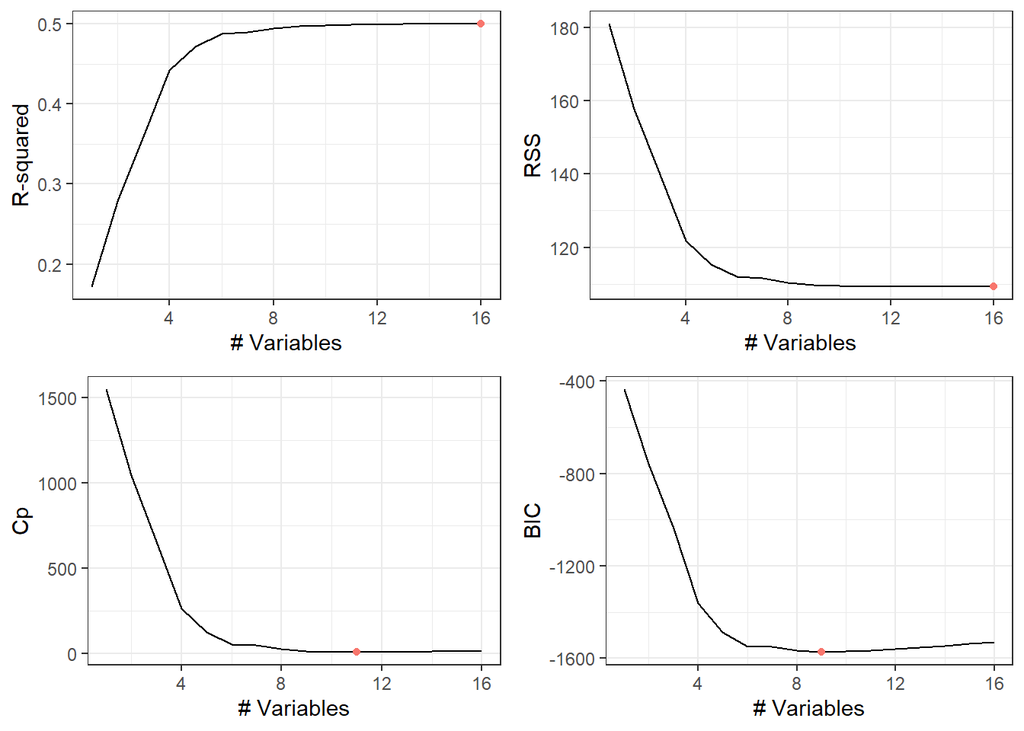

```r
num_variables <- seq(1, length(glm.summary$rss))

plot_RSQ<-ggplot(data = data.frame(glm.summary$rsq),
                 aes(x=num_variables,y=glm.summary$rsq))+
  geom_line()+
  geom_point(x=which.max(glm.summary$rsq),
             y=max(glm.summary$rsq),aes(color="red"),
             show.legend = FALSE)+
  xlab("# Variables")+
  ylab("R-squared")+
  theme_bw()


#RSS
plot_RSS<-ggplot(data = data.frame(glm.summary$rss),
                 aes(x=num_variables,y=glm.summary$rss))+
  geom_line()+
  geom_point(x=which.min(glm.summary$rss),
             y=min(glm.summary$rss),aes(color="blue"),
             show.legend = FALSE)+
  xlab("# Variables")+
  ylab("RSS")+
  theme_bw()

#BIC
plot_BIC<-ggplot(data = data.frame(glm.summary$bic),
                 aes(x=num_variables,y=glm.summary$bic))+
  geom_line()+
  geom_point(x=which.min(glm.summary$bic),
             y=min(glm.summary$bic),aes(color="green"),
             show.legend = FALSE)+
  xlab("# Variables")+
  ylab("BIC")+
  theme_bw()


#No ability to plot AIC, but is proportional to Cp
#CP
plot_CP<-ggplot(data = data.frame(glm.summary$cp),
                 aes(x=num_variables,y=glm.summary$cp))+
  geom_line()+
  geom_point(x=which.min(glm.summary$cp),
             y=min(glm.summary$cp),aes(color="yellow"),
             show.legend = FALSE)+
  xlab("# Variables")+
  ylab("Cp")+
  theme_bw()



grid.arrange(plot_RSQ, plot_RSS, plot_CP, plot_BIC, ncol=2, nrow=2)
```

The R-squared value and RSS only get better with more variables, but the Cp is at a minimum at around 11 variables, and the BIC value is at a minimum value of 9 variables.

```r
which.min(glm.summary$bic)
```

```
## [1] 9
```

Use the best subset model with 9 variables

Find the best model with 9 variables from the full data set to make sure we have the best variabels.

```r
best.nine <- regsubsets(is_intrusion~., data=traffic, nvmax = 10)
coef(best.nine, 9)
```

```
##      (Intercept) protocol_typetcp   serviceprivate  serviceftp_data
##   0.795970547844  -0.141911842027   0.404729496638   0.314545151803
##        flagError        src_bytes              hot       logged_in1
##   0.443984393619   0.000003445206  -0.057896759772   0.142540538122
##     num_rootZero  is_guest_login1
##   0.203796508461   0.966207644621
```

Build a model with these predictors from the training data

```r
glm.best <- glm(is_intrusion ~ protocol_type + service + flag + src_bytes + hot + logged_in + num_root + is_guest_login, family = binomial, data = traffic.train)
glm.bestprob <- predict(glm.best, traffic.train, type="response")
glm.bestpred <- rep(0, nrow(traffic.train))
glm.bestpred[glm.bestprob>.3] = 1
table(glm.bestpred, traffic.train$is_intrusion)
```

```
##
## glm.bestpred    0    1
##            0 2020   31
##            1  137  212
```

The variables not included in ths regression are “duration”, “dst_bytes”, and “num_access_files”. It’s surprising that “dst_bytes” was significant in the full regression, but not included in the best subsets regresion.

KNN regression

Let us check how well KNN regression model can identify intrusion.

Training KNN regression model on the train dataset created earlier.

```r
scale.traffic.train <- traffic.train %>%
  mutate_if(is.numeric, scale)

scale.traffic.test <- traffic.test %>%
  mutate_if(is.numeric, scale)


# converting factor variables to numeric - train data
scale.traffic.train$protocol_type_num = ifelse(scale.traffic.train$protocol_type == "icmp", 1,
                                           ifelse(scale.traffic.train$protocol_type == "tcp", 2,
                                                  ifelse(scale.traffic.train$protocol_type == "udp", 3, 0)))


scale.traffic.train$service_num = ifelse(scale.traffic.train$service == "http", 1,
                                           ifelse(scale.traffic.train$service == "smtp", 2,
                                                  ifelse(scale.traffic.train$service == "private", 3,
                                                         ifelse(scale.traffic.train$service == "domain_u", 4,
                                                                ifelse(scale.traffic.train$service == "ftp_data", 5,
                                                                       ifelse(scale.traffic.train$service == "other", 6, 0))))))



scale.traffic.train$flag_num = ifelse(scale.traffic.train$flag == "SF", 1,
                                           ifelse(scale.traffic.train$flag == "Error", 2, 0))


scale.traffic.train$num_root_num = ifelse(scale.traffic.train$num_root == "Non-Zero", 1,
                                           ifelse(scale.traffic.train$num_root == "Zero", 0, 2))

scale.traffic.train$logged_in_num = as.numeric(as.character(scale.traffic.train$logged_in))

scale.traffic.train$is_guest_login_num = as.numeric(as.character(scale.traffic.train$is_guest_login))




# converting factor variables to numeric - test data

scale.traffic.test$protocol_type_num = ifelse(scale.traffic.test$protocol_type == "icmp", 1,
                                           ifelse(scale.traffic.test$protocol_type == "tcp", 2,
                                                  ifelse(scale.traffic.test$protocol_type == "udp", 3, 0)))


scale.traffic.test$service_num = ifelse(scale.traffic.test$service == "http", 1,
                                           ifelse(scale.traffic.test$service == "smtp", 2,
                                                  ifelse(scale.traffic.test$service == "private", 3,
                                                         ifelse(scale.traffic.test$service == "domain_u", 4,
                                                                ifelse(scale.traffic.test$service == "ftp_data", 5,
                                                                       ifelse(scale.traffic.test$service == "other", 6, 0))))))


scale.traffic.test$flag_num = ifelse(scale.traffic.test$flag == "SF", 1,
                                           ifelse(scale.traffic.test$flag == "Error", 2, 0))


scale.traffic.test$num_root_num = ifelse(scale.traffic.test$num_root == "Non-Zero", 1,
                                           ifelse(scale.traffic.test$num_root == "Zero", 0, 2))

scale.traffic.test$logged_in_num = as.numeric(as.character(scale.traffic.test$logged_in))

scale.traffic.test$is_guest_login_num = as.numeric(as.character(scale.traffic.test$is_guest_login))



scale.traffic.train <- scale.traffic.train %>%
  mutate_if(is.numeric, scale)

scale.traffic.test <- scale.traffic.test %>%
  mutate_if(is.numeric, scale)



summary(scale.traffic.train)
```

```
##      duration.V1     protocol_type     service        flag
##  Min.   :-0.127015   icmp:  34     http    :1521   SF   :2196
##  1st Qu.:-0.127015   tcp :1949     smtp    : 232   Error: 204
##  Median :-0.127015   udp : 417     private : 193
##  Mean   : 0.000000                 domain_u: 157
##  3rd Qu.:-0.127015                 ftp_data: 131
##  Max.   :22.498465                 other   : 166
##     src_bytes.V1        dst_bytes.V1           hot.V1        logged_in
##  Min.   :-0.154365   Min.   :-0.255848   Min.   :-0.081632   0: 693
##  1st Qu.:-0.150860   1st Qu.:-0.245172   1st Qu.:-0.081632   1:1707
##  Median :-0.146753   Median :-0.220681   Median :-0.081632
##  Mean   : 0.000000   Mean   : 0.000000   Mean   : 0.000000
##  3rd Qu.:-0.143841   3rd Qu.:-0.079524   3rd Qu.:-0.081632
##  Max.   : 9.314064   Max.   :25.362125   Max.   :28.900072
##      num_root    num_access_files.V1 is_guest_login is_intrusion
##  Non-Zero:  15   Min.   :-0.03301    0:2364         0:2157
##  Zero    :2385   1st Qu.:-0.03301    1:  36         1: 243
##                  Median :-0.03301
##                  Mean   : 0.00000
##                  3rd Qu.:-0.03301
##                  Max.   :43.97592
##  protocol_type_num.V1    service_num.V1        flag_num.V1
##  Min.   :-2.8764170   Min.   :-0.6344036   Min.   :-0.304725
##  1st Qu.:-0.3958562   1st Qu.:-0.6344036   1st Qu.:-0.304725
##  Median :-0.3958562   Median :-0.6344036   Median :-0.304725
##  Mean   : 0.0000000   Mean   : 0.0000000   Mean   : 0.000000
##  3rd Qu.:-0.3958562   3rd Qu.: 0.6120709   3rd Qu.:-0.304725
##  Max.   : 2.0847046   Max.   : 2.4817827   Max.   : 3.280278
##    num_root_num.V1     logged_in_num.V1   is_guest_login_num.V1
##  Min.   :-0.079289   Min.   :-1.5691326   Min.   :-0.123378
##  1st Qu.:-0.079289   1st Qu.:-1.5691326   1st Qu.:-0.123378
##  Median :-0.079289   Median : 0.6370292   Median :-0.123378
##  Mean   : 0.000000   Mean   : 0.0000000   Mean   : 0.000000
##  3rd Qu.:-0.079289   3rd Qu.: 0.6370292   3rd Qu.:-0.123378
##  Max.   :12.606893   Max.   : 0.6370292   Max.   : 8.101809
```

```r
summary(scale.traffic.test)
```

```
##      duration.V1     protocol_type     service       flag
##  Min.   :-0.179528   icmp:  6      http    :391   SF   :549
##  1st Qu.:-0.179528   tcp :501      smtp    : 58   Error: 51
##  Median :-0.179528   udp : 93      private : 54
##  Mean   : 0.000000                 domain_u: 28
##  3rd Qu.:-0.179528                 ftp_data: 38
##  Max.   : 9.753171                 other   : 31
##     src_bytes.V1        dst_bytes.V1           hot.V1        logged_in
##  Min.   :-0.158364   Min.   :-0.397089   Min.   :-0.108168   0:154
##  1st Qu.:-0.152977   1st Qu.:-0.374939   1st Qu.:-0.108168   1:446
##  Median :-0.149960   Median :-0.329797   Median :-0.108168
##  Mean   : 0.000000   Mean   : 0.000000   Mean   : 0.000000
##  3rd Qu.:-0.146761   3rd Qu.:-0.051503   3rd Qu.:-0.108168
##  Max.   :10.182412   Max.   :12.244110   Max.   :13.319547
##      num_root   num_access_files.V1 is_guest_login is_intrusion
##  Non-Zero:  5   Min.   :-0.091593   0:591          0:543
##  Zero    :595   1st Qu.:-0.091593   1:  9          1: 57
##                 Median :-0.091593
##                 Mean   : 0.000000
##                 3rd Qu.:-0.091593
##                 Max.   :10.899618
##  protocol_type_num.V1    service_num.V1        flag_num.V1
##  Min.   :-3.0150862   Min.   :-0.6089904   Min.   :-0.304535
##  1st Qu.:-0.3818231   1st Qu.:-0.6089904   1st Qu.:-0.304535
##  Median :-0.3818231   Median :-0.6089904   Median :-0.304535
##  Mean   : 0.0000000   Mean   : 0.0000000   Mean   : 0.000000
##  3rd Qu.:-0.3818231   3rd Qu.: 0.7030177   3rd Qu.:-0.304535
##  Max.   : 2.2514399   Max.   : 2.6710299   Max.   : 3.278226
##    num_root_num.V1     logged_in_num.V1   is_guest_login_num.V1
##  Min.   :-0.091593   Min.   :-1.7003756   Min.   :-0.123301
##  1st Qu.:-0.091593   1st Qu.:-1.7003756   1st Qu.:-0.123301
##  Median :-0.091593   Median : 0.5871252   Median :-0.123301
##  Mean   : 0.000000   Mean   : 0.0000000   Mean   : 0.000000
##  3rd Qu.:-0.091593   3rd Qu.: 0.5871252   3rd Qu.:-0.123301
##  Max.   :10.899618   Max.   : 0.5871252   Max.   : 8.096741
```

```r
knn.pred = knn(scale.traffic.train[,c(1,5,6,7,10,13,14,15,16,17,18)],
               scale.traffic.test[,c(1,5,6,7,10,13,14,15,16,17,18)],
               scale.traffic.train$is_intrusion,
               k=1)

table_k1 = table(knn.pred, scale.traffic.test$is_intrusion)

sensitivity_knn_k1 <- (table_k1[2,2]/(table_k1[2,2] + table_k1[1,2]))
sensitivity_knn_k1
```

```
## [1] 0.4210526
```

```r
missclass_knn_k1 <- mean(scale.traffic.test$is_intrusion != knn.pred)
missclass_knn_k1
```

```
## [1] 0.055
```

Let us explore other k values to check for how the sensitivity varies with k-value.

```r
misclass_knn <- c()
sensitivity_knn <- c()

k.vals <- 1:15

for(kval in k.vals) {
  knn.pred.kval = knn(scale.traffic.train[,c(1,5,6,7,10,13,14,15,16,17,18)],
                      scale.traffic.test[,c(1,5,6,7,10,13,14,15,16,17,18)],
                      scale.traffic.train$is_intrusion,
                      k=kval)
  miss_knn <- mean(scale.traffic.test$is_intrusion != knn.pred.kval)
  misclass_knn <- append(misclass_knn, miss_knn)
  tab_knn <- table(knn.pred.kval, scale.traffic.test$is_intrusion)

  sens_knn <- (tab_knn[2,2]/(tab_knn[2,2] + tab_knn[1,2]))
  sensitivity_knn <- append(sensitivity_knn, sens_knn)
}

sensitivity_knn
```

```
##  [1] 0.4210526 0.4210526 0.4210526 0.5263158 0.5263158 0.5263158 0.5263158
##  [8] 0.5263158 0.5263158 0.5263158 0.5263158 0.5263158 0.5263158 0.5263158
## [15] 0.5263158
```

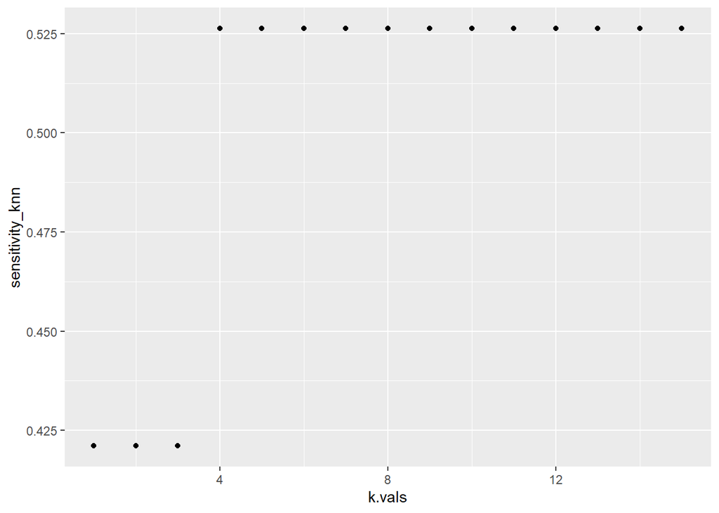

```r
qplot(k.vals, sensitivity_knn)
```

k = 4 achieves the optimum sensitivity possible with the knn model which is 0.5263158 with the set of variables selected for the prediction. Further increase in k value does not increase sensitivity of the output.

Create the final knn model with k = 4 which will be used for comparison with models derived with other methods.

```r
knn.best <- knn(scale.traffic.train[,c(1,5,6,7,10,13,14,15,16,17,18)],
                      scale.traffic.test[,c(1,5,6,7,10,13,14,15,16,17,18)],
                      scale.traffic.train$is_intrusion,
                      k=4)
```

This level of sensitivity with knn regression is not very high.

Let us create regression model Lasso method.

Lasso:

```r
x_lasso_train = model.matrix(is_intrusion ~ ., traffic.train, family = "binomial")
x_lasso_test = model.matrix(is_intrusion ~ ., traffic.test, family = "binomial")

y_lasso_train = as.numeric(as.character(traffic.train$is_intrusion))
y_lasso_test = as.numeric(as.character(traffic.test$is_intrusion))

intrusion_lasso = glmnet(x_lasso_train, y_lasso_train, alpha = 1)


coef(intrusion_lasso, s = 0.1)
```

```
## 18 x 1 sparse Matrix of class "dgCMatrix"
##                                1
## (Intercept)      0.0973848937875
## (Intercept)      .
## duration         .
## protocol_typetcp .
## protocol_typeudp .
## servicesmtp      .
## serviceprivate   .
## servicedomain_u  .
## serviceftp_data  .
## serviceother     .
## flagError        .
## src_bytes        0.0000008359044
## dst_bytes        .
## hot              .
## logged_in1       .
## num_rootZero     .
## num_access_files .
## is_guest_login1  .
```

```r
length(intrusion_lasso$lambda)
```

```
## [1] 78
```

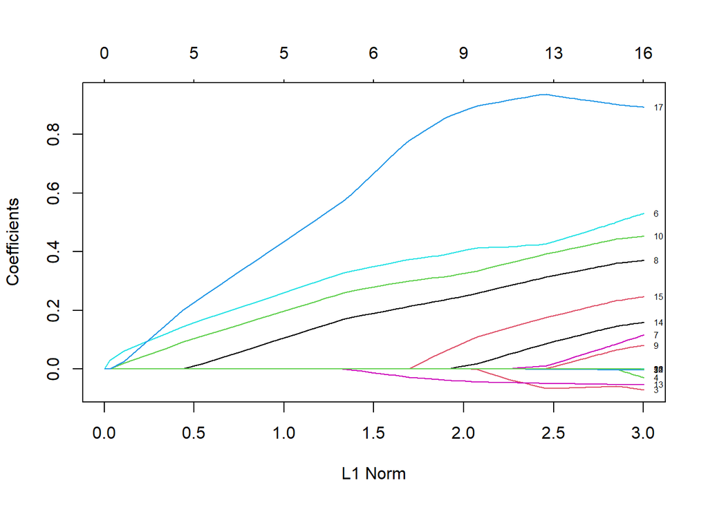

```r
plot(intrusion_lasso, label = TRUE)
```

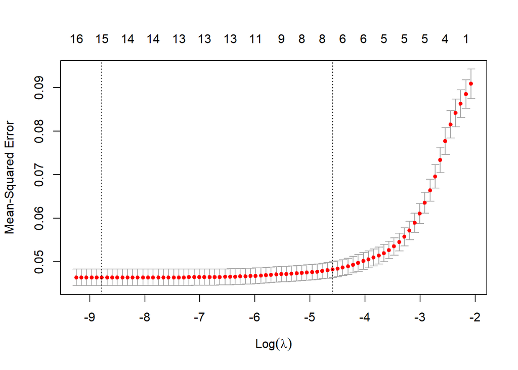

```r
cv.out_lasso = cv.glmnet(x_lasso_train, y_lasso_train, alpha = 1)
plot(cv.out_lasso)
```

```r
bestlam = cv.out_lasso$lambda.min

bestlam
```

```
## [1] 0.0001541472
```

```r
lasso.pred_lambda.min = predict(intrusion_lasso, s = bestlam, newx = x_lasso_test)

mean((lasso.pred_lambda.min - y_lasso_test)^2)
```

```
## [1] 0.04701734
```

We have 78 different lambdas in this model.

Considering cutoff value of 0.5 for the predicted value of is_intrusion for classifying it as intrusion:

```r
score.factor_lasso <- factor(as.numeric(lasso.pred_lambda.min >= .5), levels = c("0", "1"))
confusion.mat_lasso <- table(score.factor_lasso, as.factor(y_lasso_test), dnn = list("predicted", "observed"))

confusion.mat_lasso
```

```
##          observed
## predicted   0   1
##         0 540  33
##         1   3  24
```

The above confusion metrix is for cut-off value of 0.5. Now lets explore how the sensitivity and misclassification varies with the value of cut-off.

Plotting how the consideration of cut-off value impacts the sensitivity and misclassification of the lasso model:

```r
misclass_lasso <- c()
sensitivity_lasso <- c()

cutoff_lasso <- (1:15)/10

for(cutoff_lasso_i in cutoff_lasso) {
  score.factor_lasso <- factor(as.numeric(lasso.pred_lambda.min >= cutoff_lasso_i), levels = c("0", "1"))
  confusion.mat_lasso <- table(score.factor_lasso, as.factor(y_lasso_test), dnn = list("predicted", "observed"))

  miss_lasso <- mean(as.factor(y_lasso_test) != score.factor_lasso)
  misclass_lasso <- append(misclass_lasso, miss_lasso)
  tab_lasso <- table(score.factor_lasso, as.factor(y_lasso_test))

  sens_lasso <- (tab_lasso[2,2]/(tab_lasso[2,2] + tab_lasso[1,2]))
  sensitivity_lasso <- append(sensitivity_lasso, sens_lasso)
}

sensitivity_lasso
```

```
##  [1] 1.0000000 1.0000000 0.7894737 0.7894737 0.4210526 0.4210526 0.2807018
##  [8] 0.1929825 0.0877193 0.0877193 0.0877193 0.0000000 0.0000000 0.0000000
## [15] 0.0000000
```

```r
misclass_lasso
```

```
##  [1] 0.15833333 0.15166667 0.11333333 0.08333333 0.06000000 0.06000000
##  [7] 0.07000000 0.07666667 0.08666667 0.08666667 0.08666667 0.09500000
## [13] 0.09500000 0.09500000 0.09500000
```

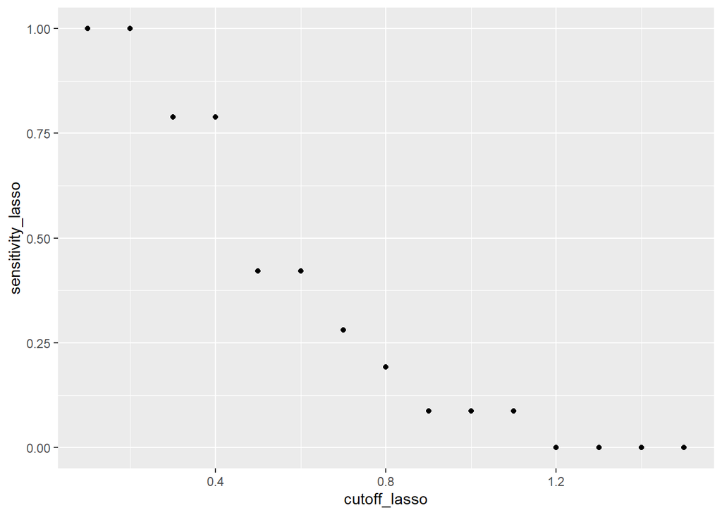

```r
qplot(cutoff_lasso, sensitivity_lasso)
```

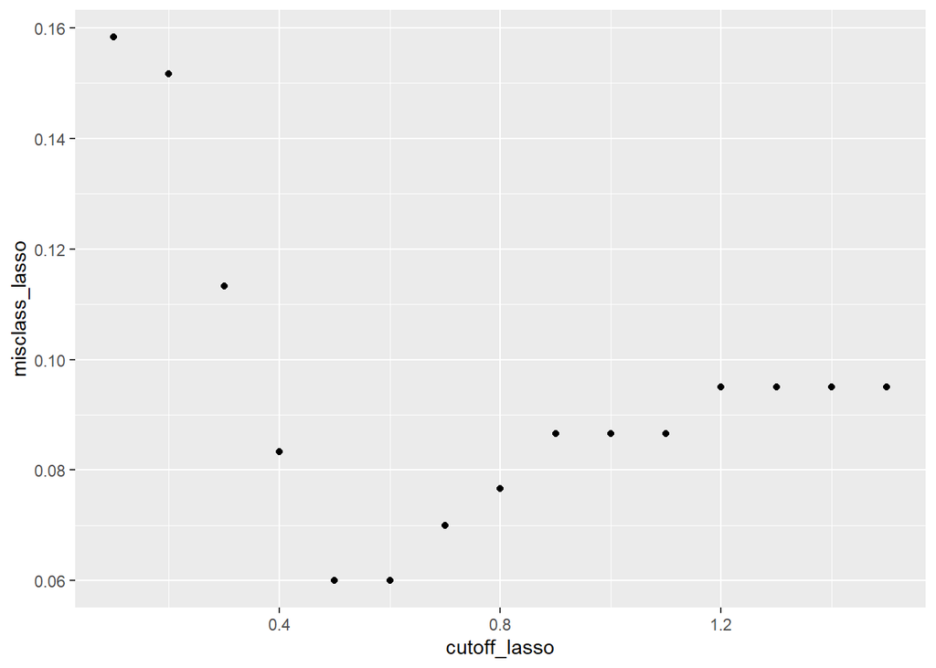

```r
qplot(cutoff_lasso, misclass_lasso)
```

Cutoff value of up to 0.2 achieves sensitivity of 1.0 and as it increases further the sensitivity reduces.

The misclassification is high towards zero value for cutoff and reduces up to 0.5 with the minimum misclassification being 0.06. It increases as cut-off increases beyond 0.5.

A balanced value of cut-off needs to be decided with trade-off between sensitivity and misclassification levels. From the plots above, it seems an ideal value of cutoff can be around 0.4 depending on the importance of achieving high sensitivity.

The optimum level of cut-off will be decided at later stage when comparing across different methods of regression.

Random forests Analysis

```r
traffic.rf <- randomForest(is_intrusion ~ ., data = traffic.train)
traffic.rf
```

```
##
## Call:
##  randomForest(formula = is_intrusion ~ ., data = traffic.train)
##                Type of random forest: classification
##                      Number of trees: 500
## No. of variables tried at each split: 3
##
##         OOB estimate of  error rate: 4.46%
## Confusion matrix:
##      0   1 class.error
## 0 2157   0   0.0000000
## 1  107 136   0.4403292
```

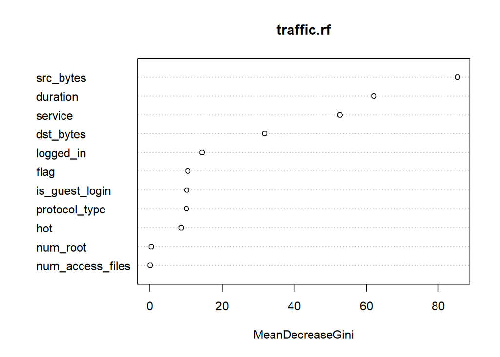

```r
var.imp.rf <- varImpPlot(traffic.rf)
```

```r
# most important variables ranked

rownames(var.imp.rf)[order(var.imp.rf, decreasing = TRUE)]
```

```
##  [1] "src_bytes"        "duration"         "service"          "dst_bytes"
##  [5] "logged_in"        "flag"             "is_guest_login"   "protocol_type"
##  [9] "hot"              "num_root"         "num_access_files"
```

```r
# The variables are ranked above based on their importance. src_bytes, duration, service and dst_bytes seems to be most important for is_intrusion.


rf.test.prob <- predict(traffic.rf, newdata = traffic.test, type = "prob")[,"1"]



score.factor_rf <- factor(as.numeric(rf.test.prob >= .5), levels = c("0", "1"))
confusion.mat_rf <- table(score.factor_rf, as.factor(traffic.test$is_intrusion), dnn = list("predicted", "observed"))

confusion.mat_rf
```

```
##          observed
## predicted   0   1
##         0 543  27
##         1   0  30
```

```r
mean((rf.test.prob - as.numeric(as.character(traffic.test$is_intrusion)))^2)
```

```
## [1] 0.03045818
```

In the above plot we have considered the cutoff value of 0.5 for the predicted value of is_intrusion for classifying it as intrusion. Now lets explore how the sensitivity and misclassification varies with the value of cut-off.

Plotting how the consideration of cut-off value impacts the sensitivity and misclassification of the Random Forest model:

```r
y_rf_test = as.numeric(as.character(traffic.test$is_intrusion))


misclass_rf <- c()
sensitivity_rf <- c()

cutoff_rf <- (1:15)/10

for(cutoff_rf_i in cutoff_rf) {
  score.factor_rf_vec <- factor(as.numeric(rf.test.prob >= cutoff_rf_i), levels = c("0", "1"))
  confusion.mat_rf_vec <- table(score.factor_rf_vec, as.factor(y_rf_test), dnn = list("predicted", "observed"))

  miss_rf <- mean(as.factor(y_rf_test) != score.factor_rf_vec)
  misclass_rf <- append(misclass_rf, miss_rf)
  tab_rf <- table(score.factor_rf_vec, as.factor(y_rf_test))

  sens_rf <- (tab_rf[2,2]/(tab_rf[2,2] + tab_rf[1,2]))
  sensitivity_rf <- append(sensitivity_rf, sens_rf)
}

sensitivity_rf
```

```
##  [1] 0.8771930 0.8596491 0.8596491 0.5263158 0.5263158 0.5263158 0.5263158
##  [8] 0.4385965 0.4210526 0.0000000 0.0000000 0.0000000 0.0000000 0.0000000
## [15] 0.0000000
```

```r
misclass_rf
```

```
##  [1] 0.05000000 0.03833333 0.03833333 0.04500000 0.04500000 0.04500000
##  [7] 0.04500000 0.05333333 0.05500000 0.09500000 0.09500000 0.09500000
## [13] 0.09500000 0.09500000 0.09500000
```

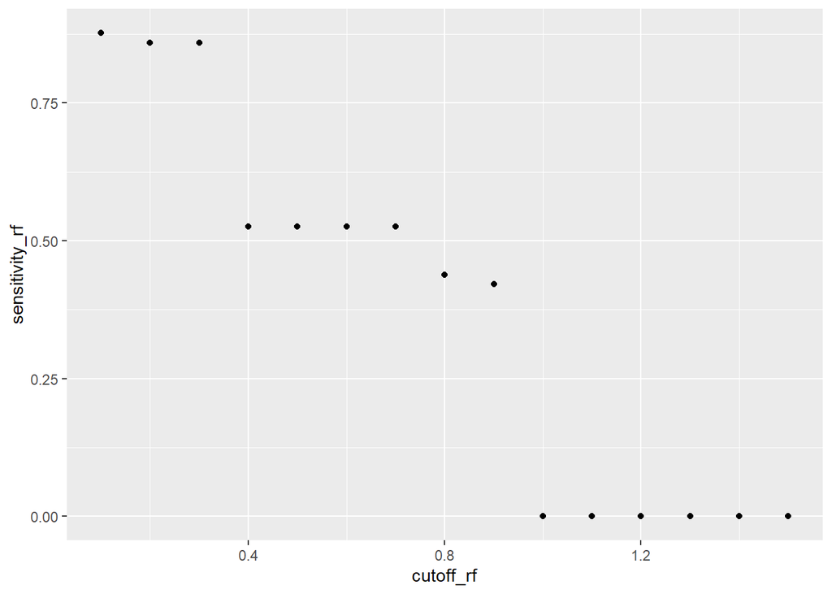

```r
qplot(cutoff_rf, sensitivity_rf)
```

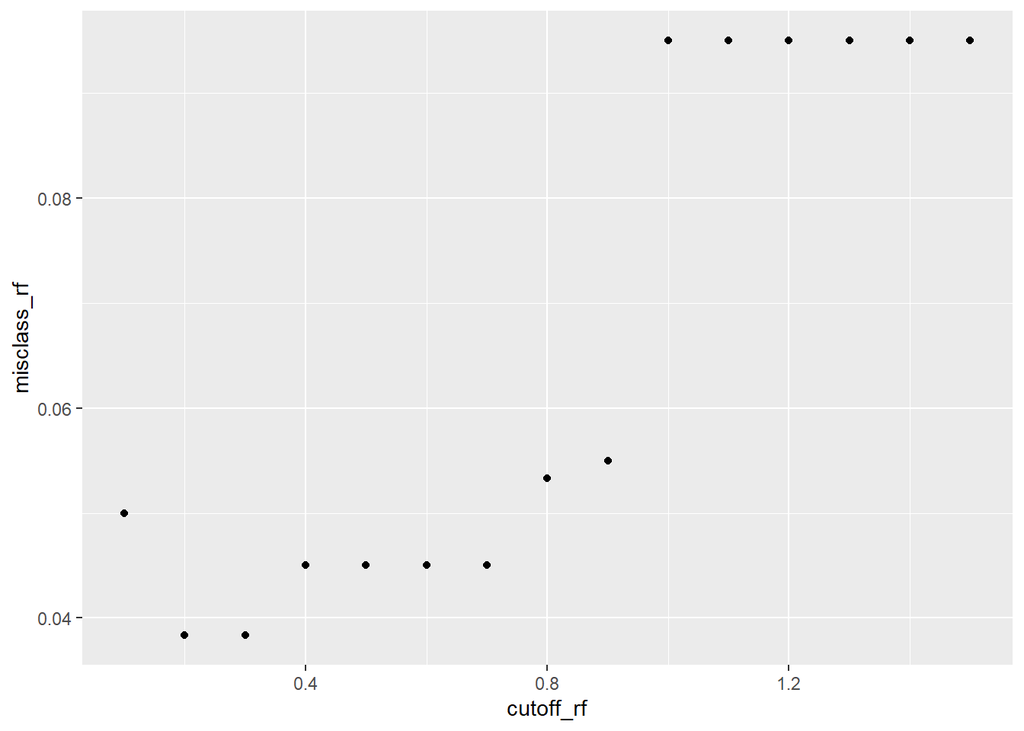

```r
qplot(cutoff_rf, misclass_rf)
```

Cutoff value of up to 0.1 achieves sensitivity of .9 and as it increases further the sensitivity reduces.

A balanced value of cut-off needs to be decided with trade-off between sensitivity and misclassification levels. From the plots above, it seems an ideal value of cutoff can be around 0.3 depending on the importance of achieving high sensitivity.

The optimum level of cut-off will be decided at later stage when comparing across different methods of regression.

Pruned Decision Trees:

We have followed the same method as above to do analysis with pruned trees.

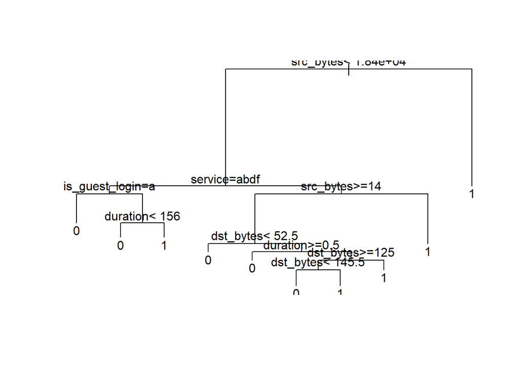

```r
traffic.tree <- rpart(is_intrusion ~ ., data = traffic.train)
plot(traffic.tree)
text(traffic.tree)
```

```r
print(traffic.tree)
```

```
## n= 2400
##
## node), split, n, loss, yval, (yprob)
##       * denotes terminal node
##
##   1) root 2400 243 0 (0.89875000 0.10125000)
##     2) src_bytes< 18395.5 2323 168 0 (0.92767972 0.07232028)
##       4) service=http,smtp,domain_u,other 2026  56 0 (0.97235933 0.02764067)
##         8) is_guest_login=0 1990  29 0 (0.98542714 0.01457286) *
##         9) is_guest_login=1 36   9 1 (0.25000000 0.75000000)
##          18) duration< 156 9   0 0 (1.00000000 0.00000000) *
##          19) duration>=156 27   0 1 (0.00000000 1.00000000) *
##       5) service=private,ftp_data 297 112 0 (0.62289562 0.37710438)
##        10) src_bytes>=14 264  80 0 (0.69696970 0.30303030)
##          20) dst_bytes< 52.5 90   0 0 (1.00000000 0.00000000) *
##          21) dst_bytes>=52.5 174  80 0 (0.54022989 0.45977011)
##            42) duration>=0.5 17   1 0 (0.94117647 0.05882353) *
##            43) duration< 0.5 157  78 1 (0.49681529 0.50318471)
##              86) dst_bytes>=125 150  72 0 (0.52000000 0.48000000)
##               172) dst_bytes< 145.5 20   2 0 (0.90000000 0.10000000) *
##               173) dst_bytes>=145.5 130  60 1 (0.46153846 0.53846154) *
##              87) dst_bytes< 125 7   0 1 (0.00000000 1.00000000) *
##        11) src_bytes< 14 33   1 1 (0.03030303 0.96969697) *
##     3) src_bytes>=18395.5 77   2 1 (0.02597403 0.97402597) *
```

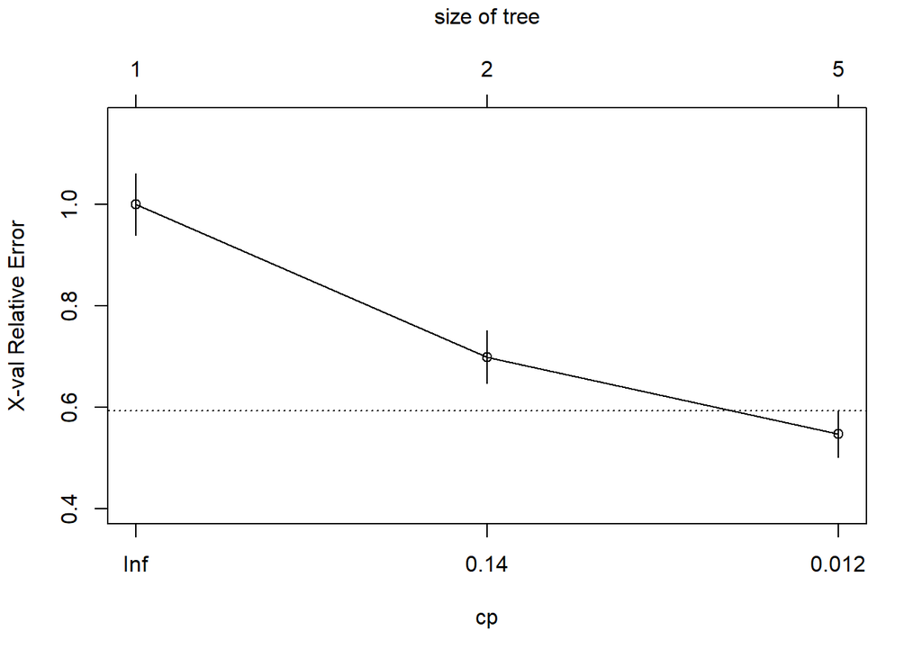

```r
traffic.train_prune <- rpart(is_intrusion ~ ., data = traffic.train,
                        control = rpart.control(minsplit=100, cp=0.002))

# Running the `plotcp` command on this tree. Also looking at the `cptable` attribute of `marketing.full`

plotcp(traffic.train_prune)
```

```r
traffic.train_prune$cptable
```

```
##           CP nsplit rel error    xerror       xstd
## 1 0.30041152      0 1.0000000 1.0000000 0.06081578
## 2 0.06721536      1 0.6995885 0.6995885 0.05172077
## 3 0.00200000      4 0.4979424 0.5473251 0.04612535
```

```r
# Applying the 1-SE rule to determine which value of cp to use for pruning


min.cv.idx <- which.min(traffic.train_prune$cptable[,"xerror"])

# min CV error + 1se (this is the height of the horizontal bar)

min.cv.err.1se <- traffic.train_prune$cptable[min.cv.idx,"xerror"] +
                    traffic.train_prune$cptable[min.cv.idx,"xstd"]

# Which cp values produce models whose error is below min CV + 1se?

candidate.cp.vals <- traffic.train_prune$cptable[which(traffic.train_prune$cptable[,"xerror"] < min.cv.err.1se),"CP"]

# 1-SE rule value of cp
cp.1se <- max(candidate.cp.vals)
print(cp.1se)
```

```
## [1] 0.002
```

1-SE rule value of cp = 0.002